## MS/MS Spectrum Analysis & Auto-Assignment

Mass spectrometry takes advantage of MS/MS spectra to provide sequence information of peptide. One has to, however, scrutinize each MS/MS spectrum when it comes to locate the residue that’s been covalently labeled. The *motivation* of writing this app is to achieve automatic MS/MS spectrum assignments and annotations.

### **in silico** Fragments

- Generate a list of b-/y-ion series of a given peptide
- Incorporate residue-level modifications
- Have the option to include user-specified neutral loss

**Shown below is an example of the daughter-ion list.**

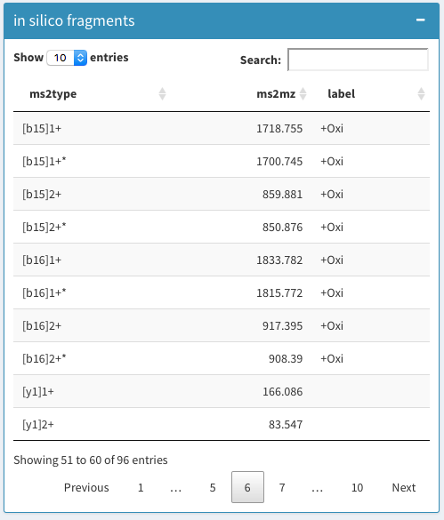

### Peaks Matching

- Read mzXML file ONLY
- Display MS/MS spectrum and stats (RT, precursor m/z, charge state) with given scan i.d.

**Shown below is an example of the stats box.**

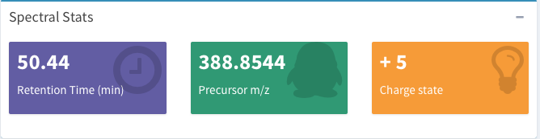

- Annotate spectrum with user-defined parameters

**Shown below is an example of the MS/MS spectrum.**

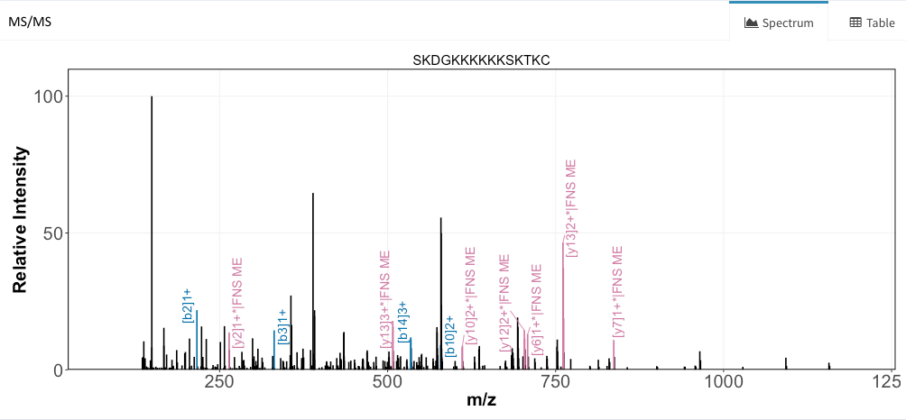

- Display annotated peaks in Table, which allows selective removal of annotations

**Shown below is an example of the Table that contains all the annotated peaks.**

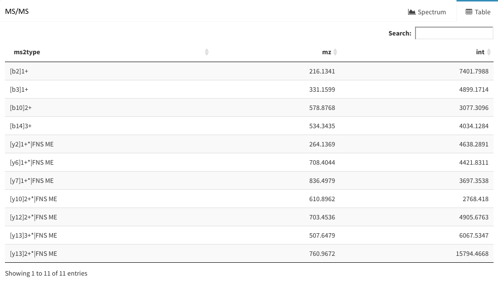

- Output MS/MS spectrum with user-defined resolution (ppi) and Table